# Lab 4, Zad 2

## Obraz binarny

Celem ćwiczenia jest zobrazowanie działania algorytmu wyżarzania w kontekście różnych funkcji kosztu, aby zrozumieć, jak zmienia się jego skuteczność w zależności od charakterystyki problemu.

# Importy

```python
import numpy as np
import matplotlib.pyplot as plt
import math
import random
from PIL import Image
```

# Funkcje przydatne do wizualizacji

Funckcja `create_image_from_array` tworzy obraz z macierzy

```python
def create_image_from_array(matrix):
    # Pillow interpretuje 0 jako czarny, 255 jako biały w trybie 'L' (8-bit grayscale)
    arr = (1 - matrix.astype(np.uint8)) * 255  # 1 -> 0 (czarny), 0 -> 255 (biały)
    return Image.fromarray(arr, mode='L')
```

Funkcja `draw_plot(array)` rysuje obraz z macierzy

```python
def draw_plot(matrix, path = None, folder_name = ''):
    n = len(matrix)
    img = Image.new('1', (n, n))  # Tworzymy obraz o wymiarach NxN, gdzie '1' oznacza obraz w odcieniach szarości

    # Zmiana pikseli na podstawie tablicy
    pixels = img.load()
    for i in range(n):
        for j in range(n):
            pixels[j, i] = int(matrix[i, j])  # 0 to biały, 1 to czarny

    # Zapisywanie obrazu
    img.save(f"zad2_images/images/{folder_name}/{path}.png")
```

Funkcja `extend_gif(matrix,images)` dodaje kolejną klatke do gifu

```python
def extend_gif(matrix,images):
    n = len(matrix)
    img = Image.new('1', (n, n))  # '1' oznacza obraz czarno-biały
    pixels = img.load()
    for i in range(n):
        for j in range(n):
            pixels[j, i] = int(matrix[i, j])

    images.append(img) # 0 to biały, 1 to czarny
    return images
```

Funkcja `draw_linear_plot` rysuje wykres liniowy z tablicy energii

```python
def draw_linear_plot(energy_tab, file_name = None, folder_name = ''):
    plt.figure()
    plt.title(f"Funkcja kosztu dla {file_name}")
    plt.xlabel('Liczba iterazcji')
    plt.ylabel('Wyliczona funkcja')
    plt.plot(energy_tab)
    if file_name:
        plt.savefig(f"zad2_images/plots/{folder_name}/{file_name}.png")
    plt.close()
```

# Rozwiązanie

Do modelu wykorzystuje funkcje temperatury opratą o ciąg geometryczny

```python
def update_temp_geo(Temp, a, k ,temp_start):
    return a * Temp
```

Funkcja prawdopodobieństwa z zadania 1

```python
def propability(diffrance, Temp):
    if diffrance < 0:
        return 1
    return np.exp(-diffrance/ Temp)
```

Funkcja `get_random_points(all_cords, n)` zwaraca dwie tablice losowych kordynatów punktów w macierzy o wielkości `n`

Funckja `get_all_cords(matrix)` zwraca tablice krotek indeksów tablicy

```python
def get_random_points(all_cords, n):
        return random.sample(all_cords, n), random.sample(all_cords, n)

def get_all_cords(matrix):
        return [(x, y) for x in range(len(matrix)) for y in range(len(matrix))]
```

Funkcja `calc_total_energy` oblicza całkowitą energię układu na podstawie podanej funkcji `calc_for_point`, która definiuje sposób oceny pojedynczej komórki. Dla każdej komórki w macierzy wynik tej funkcji jest sumowany, tworząc globalną wartość energii.

Funkcja `calc_diff_energy` zwraca różnicę w energii układu wynikającą z zamiany miejscami dwóch punktów: (x1, y1) i (x2, y2). Wykorzystuje przy tym tę samą funkcję `calc_for_point`, by oszacować zmianę lokalnej energii przed i po zamianie.

Obie funkcje pełnią rolę uniwersalnego interfejsu, który ułatwia testowanie różnych funkcji optymalizujących bez konieczności modyfikowania głównej logiki algorytmu.

```python
def calc_total_energy(M, calc_for_point):
    n = len(M)
    total = 0
    for i in range(n):
        for j in range(n):
            total += calc_for_point(M, i, j, M[i][j])
    return total // 2  # unikamy podwójnego liczenia

def calc_diff_energy(M, x1, y1, x2, y2, calc_for_point):
    sum = 0
    sum -= calc_for_point(M, x1, y1, M[x1][y1])
    sum -= calc_for_point(M, x2, y2, M[x2][y2])
    sum += calc_for_point(M, x1, y1, M[x2][y2])
    sum += calc_for_point(M, x2, y2, M[x1][y1])
    return sum
```

## Główna funkcja

Funkcja `create_cristal` realizuje proces optymalizacji przy użyciu algorytmu symulowanego wyżarzania (simulated annealing) na macierzy binarnej (z wartościami 0 i 1), której celem jest minimalizacja zadanej funkcji celu dla pojedynczych komórek (fun_to_optymalize). Dodatkowo może tworzyć animowany GIF ilustrujący przebieg optymalizacji.

Argumenty:

- matrix (np.ndarray): Macierz binarna (0 i 1), która reprezentuje stan układu.
- fun_to_optymalize (callable): Funkcja celu dla pojedynczej komórki, wykorzystywana do obliczenia energii układu.
- temp_start (float): Początkowa temperatura procesu wyżarzania.
- loop_limit (int): Liczba iteracji algorytmu.
- min_heat (float) (domyślnie: 1e-2): Minimalna temperatura, poniżej której proces zostaje zatrzymany.
- fun_change_par (float) (domyślnie: 0.99993): Współczynnik zmniejszania temperatury.
- fun_temp_change (callable) (domyślnie: update_temp_geo): Funkcja aktualizująca temperaturę (np. wykładnicze chłodzenie).
- gif_name (str | None): Nazwa pliku GIF-a, jeśli animacja ma zostać zapisana.

Działanie:

- Inicjalizuje temperaturę, energię układu i historię wartości funkcji celu.
- W każdej iteracji losuje parę punktów 0 i 1, oblicza różnicę energii i z prawdopodobieństwem zależnym od temperatury decyduje o akceptacji zmiany.
- Jeśli zostanie osiągnięte nowe najlepsze rozwiązanie, zapisuje je.
- Co pewną liczbę iteracji (100 równomiernie rozłożonych klatek) dodaje stan macierzy do listy klatek GIF-a.
- Aktualizuje temperaturę zgodnie z podaną funkcją.
- Na końcu zapisuje animację GIF i zwraca końcową macierz, historię energii oraz najlepszą wartość funkcji celu.

Zwraca:

- matrix (np.ndarray): Zoptymalizowana macierz.
- optymalized_tab (list[float]): Historia wartości funkcji celu.
- best_val (float): Najlepsza uzyskana wartość funkcji celu.

Następny stan jest uzyskiwany poprzez zamianę co najmniej ${2n}/100$ punktów między sobą. Proces ten zależy również od temperatury – im wyższa temperatura, tym więcej punktów zmienia się jednocześnie. Taki sposób modyfikacji pozytywnie wpływa na dynamikę tworzenia rysunku, wprowadzając pewną zmienność przy minimalnym wpływie na jego dokładność. Tego typu fluktuacje dobrze odwzorowują rzeczywiste procesy krystalizacji, gdzie asymetrie, niedoskonałości i inne nieregularności są nieodłączną częścią struktury.

Dodatkowo dla przyspieszenia generowania obrazów nie zapisuje najlepszego stanu. Zwracam ostatni stan jaki był w pętli. Przyspieszyło to algorytm kilkukrotnie

```python
def create_cristal(matrix,
                 fun_to_optymalize,
                 temp_start,
                 loop_limit,
                 min_heat=1e-2,
                 fun_change_par=0.99993,
                 fun_temp_change=update_temp_geo,
                 gif_name=None,
                ):

    # biore zawsze 100 klatek
    checkpoints_for_gif = np.linspace(0, loop_limit, 100)
    checkpoints_for_gif = np.round(checkpoints_for_gif).astype(int)
    eps = 10**(-8)
    temp = temp_start
    all_cords = get_all_cords(matrix)
    best_val = calc_total_energy(matrix,fun_to_optymalize)  # Obliczenie początkowej długości trasy
    prev_val = best_val# Zapamiętanie najlepszego dotąd rozwiązania
    optymalized_tab = [best_val]  # Historia długości tras
    n = len(matrix)
    # Przygotowanie listy na obrazy do animacji
    if gif_name:
        gif_filename = f"zad2_images/gifs/{gif_name}.gif"
        images = []

    for i in range(loop_limit):
        if temp < min_heat:
            # Zatrzymanie, jeśli temperatura spadła poniżej progu
            break

        # Zamiana dwóch losowych punktów
        points1_choice, points2_choice = get_random_points(all_cords, max(int(n//100),int(n//100*(temp+1))))
        diff =0
        # Obliczenie zmiany długości trasy po zamianie
        for point1,point2 in zip(points1_choice,points2_choice):
            diff += calc_diff_energy(matrix, point1[0], point1[1], point2[0], point2[1],fun_to_optymalize)

        # diff = calc_diff_fun(matrix, i_swap1, j_swap1, i_swap2, j_swap2)
        new_val = diff + prev_val

        # Akceptacja zmiany z prawdopodobieństwem zależnym od temperatury
        if np.random.uniform(0, 1) < propability(diff, temp):
            for point1,point2 in zip(points1_choice,points2_choice):
                i_swap1,j_swap1 = point1
                i_swap2,j_swap2 = point2
                matrix[i_swap1][j_swap1], matrix[i_swap2][j_swap2] = matrix[i_swap2][j_swap2], matrix[i_swap1][j_swap1]
            if new_val - best_val < -eps:
                # Aktualizacja najlepszego rozwiązania
                best_val = new_val

            prev_val = new_val
        if i in checkpoints_for_gif:
            if gif_name:
                # Dodanie klatki do GIF-a
                images = extend_gif(matrix,images)
        optymalized_tab.append(prev_val)

        # Aktualizacja temperatury zgodnie z wybraną funkcją
        temp = fun_temp_change(temp, fun_change_par, i, temp_start)

    # Zapisanie animacji GIF, jeśli podano nazwę pliku
    if gif_name:
        images[0].save(gif_filename, save_all=True, append_images=images[1:], duration=100, loop=0)

    return matrix, optymalized_tab, best_val
```

## Wizualizacja różnorodnych funkcji optymalizujących

Uwaga:

Przetestowałem wcześniej wszystkie funkcje spadku temperatury z pierwszego zadania. Po ich analizie doszedłem do wniosku, że różnice między nimi są niewielkie, a ewentualne rozbieżności jedynie zwiększają poziom szumu. W związku z tym zdecydowałem się wykorzystać funkcję wykładniczą jako podstawową funkcję w wszystkich dalszych wizualizacjach.

Dodatkowo, w celu uzyskania bardziej przejrzystego porównania warunków żarzenia, zdecydowałem się ograniczyć manipulacje parametrami jedynie do temperatury początkowej. Parametr ten dobrze obrazuje wpływ większej zmienności na ogólny przebieg procesu.

W celu zautomatyzowania procesu tworzenia obrazów, zaimplementowałem funkcję `implement_fun_for_matrix`, która generuje obrazy na podstawie różnych parametrów: prawdopodobieństwa pojawienia się czarnego punktu (`t_delta`), dopuszczalnej liczby iteracji (`t_iter`), rozmiaru obrazu (`t_size`) oraz początkowej temperatury (`t_start_temp`). Funkcja ta pozwala na eksperymentowanie z różnymi ustawieniami, co umożliwia uzyskanie obrazów o różnych cechach w zależności od zadanych parametrów.

```python
def implement_fun_for_matrix(fun_to_optymalize, name):
    t_delta = [0.1,0.3,0.4,0.6]
    t_iter = [100000, 500000]
    t_size = [128,256,512,1024]
    t_start_temp = [1, 30]
    for iter in t_iter:
            for delta in t_delta:
                for size in t_size:
                    for start_temp in t_start_temp:
                        if start_temp == 30 and iter == 500000: continue
                        matrix, t, _ = create_cristal(np.random.choice([0, 1], size=(size, size), p=[delta, 1-delta]) ,
                                        fun_to_optymalize,
                                        start_temp,
                                        iter,
                                        min_heat=1e-18,
                                        fun_change_par=0.99999,

                                        gif_name=f"{name}/{name}_{size}x{size}_{delta}_{iter}t{start_temp}")
                        draw_linear_plot(t,f"{name}_{size}x{size}_{delta}_{iter}t{start_temp}",name)
                        draw_plot(matrix,f"{name}_{size}x{size}_{delta}_{iter}t{start_temp}",name)
```

Oznaczenie nazw plików:

- Pierwszy człon określa nazwę funkcji do optymalizacji
- Drugi określa wielkość obrazu
- Trzeci definiuje prawdopodobieństwo pojawienia się czarnego punktu podczas generowania obrazu
- Czwarty pokazuje liczbe przeprowadzonych iteracji
- Litera rozdzielająca "t"
- Ostatni człon to temperatura początkowa

## Implementacje funkcji kosztu

## Funckje bazujące na sąsiedztwie danego punktu

### 1. 4-sąsiedztwo

Ta funkcja kara za niegrupowanie się punktów na mapie. Swoim zasięgiem obejmuje tylko tereny bezpośrednio przyległe do danego punktu

```python
def four_neighborhood_cell_val(M, x, y, val):
    n = len(M)
    total = 0
    for d in [-1, 1]:
        nx, ny = x + d, y + d
        if 0 <= nx < n and 0 <= ny < n:
            if M[nx][y] != val:
                total += 1
            if M[x][ny] != val:
                total += 1
    return total
```

Tworzenie gifów i obrazów

```python
implement_fun_for_matrix(four_neighborhood_cell_val, "4_neighborhood")
```

Wizualizacje

$δ = $ 0.4, iter = 500000, temp_start = 1

[figure not shown]

size = 256, $δ = $ 0.6, iter = 500000, temp_start = 1

[figure not shown]

size = 1024, $δ = $ 0.3, iter = 500000, temp_start = 1

[figure not shown]

Czarne punkty wykazują wyraźną tendencję do formowania skupisk, które przybierają postać mniejszych lub większych struktur

### 2. 8-sąsiedztwo

Ta funkcja penalizuje brak grupowania punktów na mapie. Jest zbliżona do koncepcji 4-sąsiedztwa, jednak w odróżnieniu od niego, jej zasięg obejmuje obszary oddalone o jedną jednostkę w metryce maksimum.

```python
def eight_neighborhood_cell_val(M, x, y, val):
    n = len(M)
    total = 0
    for dx in [-1, 0, 1]:
        for dy in [-1, 0, 1]:
            if dx == 0 and dy == 0:
                continue  # pomijamy środek
            nx, ny = x + dx, y + dy
            if 0 <= nx < n and 0 <= ny < n:
                if M[nx][ny] != val:
                    total += 1
    return total
```

Tworzenie gifów i obrazów

```python
implement_fun_for_matrix(eight_neighborhood_cell_val, "8_neighborhood")
```

Wizualizacje i gify

size = 128, $δ = $ 0.6, iter = 500000, temp_start = 1

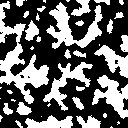

size = 512, $δ = $ 0.6, iter = 500000, temp_start = 1

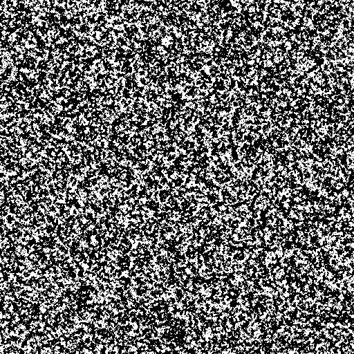

size = 1024, $δ = $ 0.6, iter = 500000, temp_start = 1

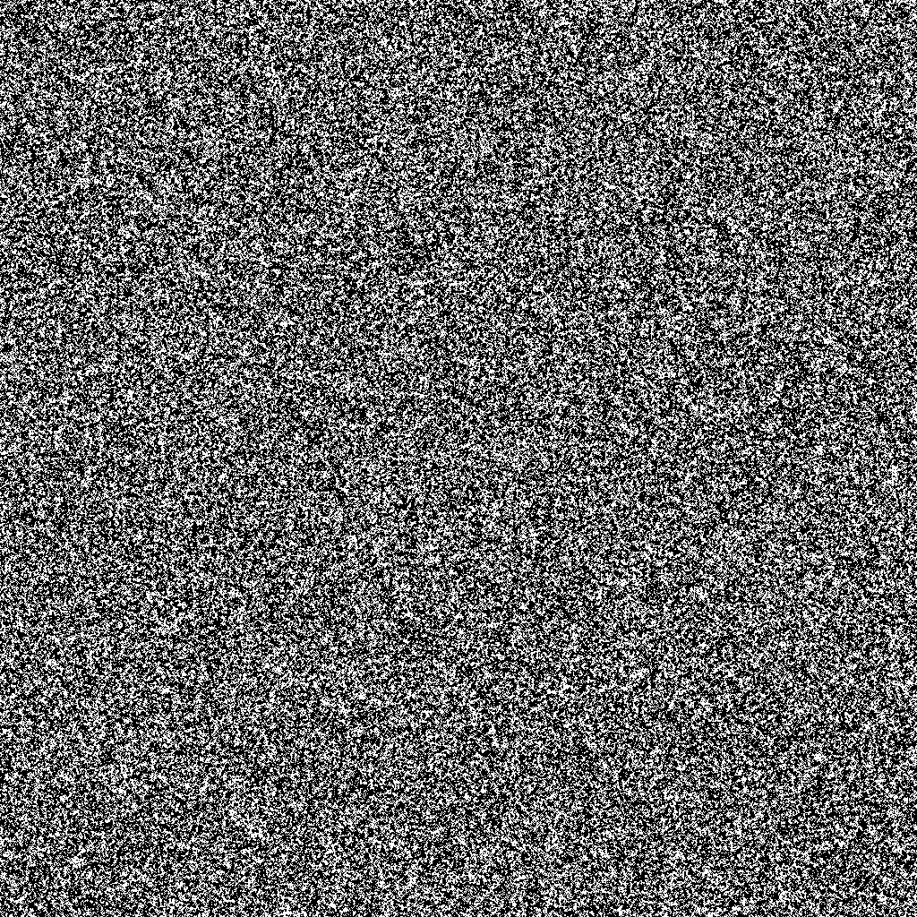

Zaobserwowane skupiska punktów są większe w porównaniu do 4-sąsiedztwa, co wynika z faktu, że premiowane jest nie tylko bezpośrednie przyleganie, ale także szersze sąsiedztwo, obejmujące punkty oddalone o jedną jednostkę w metryce maksimum.

## 3. 16-sąsiedztwo

```python
def sixteen_neighborhood_cell_val(M, x, y, val):
    n = len(M)
    total = 0
    # Rozważamy 16 sąsiednich komórek wokół (x, y)
    for dx in [-2, -1, 0, 1, 2]:  # Umożliwiamy przesunięcia o 2 jednostki
        for dy in [-2, -1, 0, 1, 2]:
            if abs(dx) == 2 and abs(dy) == 2:continue
            if dx == 0 and dy == 0:
                continue  # Pomijamy środek
            nx, ny = x + dx, y + dy
            if 0 <= nx < n and 0 <= ny < n:  # Sprawdzamy, czy sąsiedzi mieszczą się w obrębie macierzy
                if M[nx][ny] != val:  # Sprawdzamy, czy różni się od wartości 'val'
                    total += 1
    return total
```

Tworzenie gifów i obrazów

```python
implement_fun_for_matrix(sixteen_neighborhood_cell_val, "16_neighborhood")
```

size = 128, $δ = $ 0.6, iter = 100000, temp_start = 1

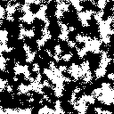

size = 256, $δ = $ 0.4, iter = 500000, temp_start = 1

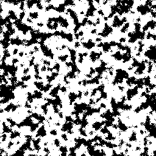

size = 1024, $δ = $ 0.3, iter = 500000, temp_start = 1

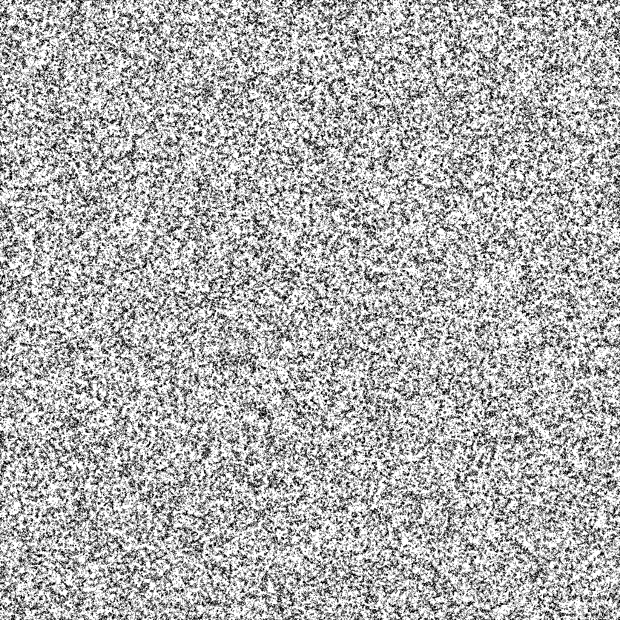

Dla grup tworzonych przez tę funkcję obserwujemy wyraźną nieregularność na ich brzegach. Wiele punktów nie przylega bezpośrednio do innych, co prowadzi do interesującego efektu "poszarpania" na krawędziach grup. Jest to wynikiem zastosowanego kryterium, w którym punkt uznawany za „dobry” może znajdować się również w odległości dwóch pól, co wpływa na kształt i strukturę tych grup.

## 4. Vertical

Ta funkcja nakłada karę za obecność sąsiedztwa w kierunku pionowym.

```python
# kolory lubią być koło swoich
def vertical_cell_val(M, x, y, val):
    n = len(M)
    total = 0
    for d in [-1, 1]:
        nx = x + d
        if 0 <= nx < n:
            if M[nx][y] != val:
                total += 1
    return total
```

Wizualizacje i gify

```python
implement_fun_for_matrix(vertical_cell_val, "vertical")
```

size = 128, $δ = $ 0.3, iter = 500000, temp_start = 1

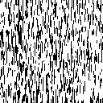

size = 256, $δ = $ 0.4, iter = 500000, temp_start = 1

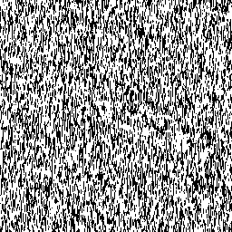

size = 512, $δ = $ 0.1, iter = 500000, temp_start = 1

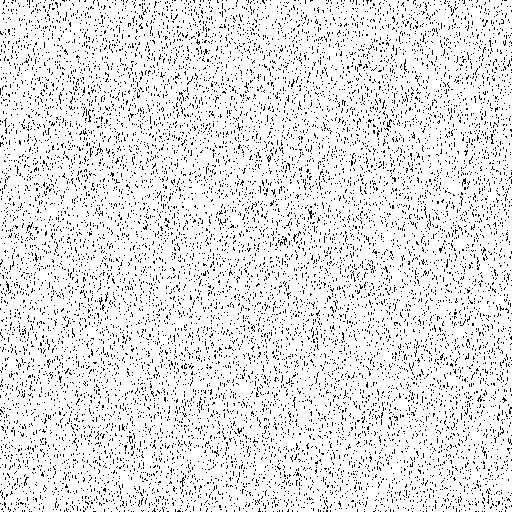

Kryształy formują strukturę przypominającą drewno, jednak w przypadku większych obrazów ten efekt staje się coraz mniej wyraźny. Zamiast tego, dostrzegamy jedynie pojedyncze obszary, które zostały zorganizowane w sposób zwertykalizowany.

## 5. Szachownica

Funkcja ta nakłada karę za obecność sąsiadów o różnych kolorach po przekątnej. Jej celem jest wymuszenie struktury, która przypomina klasyczną szachownicę, gdzie sąsiadujące pola mają naprzemiennie różne kolory, zarówno w poziomie, jak i w pionie, z wyraźnie zaznaczoną regularnością w układzie.

```python
# kolory lubią być koło swoich
def small_chess_cell_val(M, x, y, val):
    n = len(M)
    total = 0
    for dx in [-1, 0, 1]:
        for dy in [-1, 0, 1]:
            if dx == 0 or dy == 0:
                continue  # pomijamy środek
            nx, ny = x + dx, y + dy
            if 0 <= nx < n and 0 <= ny < n:
                if M[nx][ny] != val:
                    total += 1
    return total
```

Wizualizacja i gify

```python
implement_fun_for_matrix(small_chess_cell_val, "chess")
```

size = 128, $δ = $ 0.6, iter = 500000, temp_start = 1

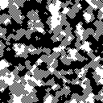

size = 128, $δ = $ 0.3, iter = 500000, temp_start = 1

[figure not shown]

size = 256, $δ = $ 0.6, iter = 500000, temp_start = 1

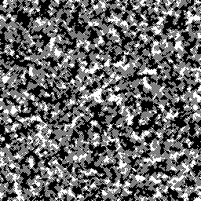

size = 512, $δ = $ 0.4, iter = 500000, temp_start = 1

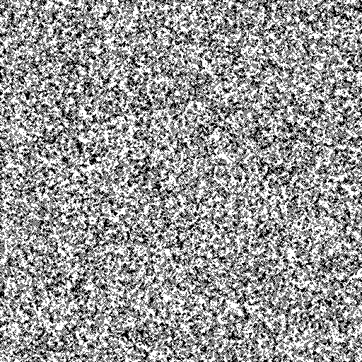

Co interesujące, wygenerowane obrazy nie tyle przywodzą na myśl klasyczną szachownicę, ile raczej przypominają mapę topograficzną. Wydaje się, że obraz składa się z trzech dominujących kolorów: czarnego, białego i szarego. W rzeczywistości, szary kolor powstaje w wyniku interakcji białego i czarnego, tworząc wzór przypominający szachownicę. Dodając do tego tendencję do grupowania obiektów, wynikającą z funkcji kosztu, otrzymujemy estetyczny, „trójkolorowy” obraz o wyraźnie zdefiniowanych strukturach.

## 6. Labirynt

Funkcja ta wprowadza restrykcje, które wymagają, aby punkt najbliżej przekątnej miał inny kolor niż punkt znajdujący się o jedno pole dalej, który powinien być tego samego koloru. Tego rodzaju zasady prowadzą do powstania struktury przypominającej labirynt, w której kolory tworzą złożoną sieć, przypominającą ścieżki i ściany w labiryncie.

```python
# kolory lubią być koło swoich
def lab_cell_val(M, x, y, val):
    n = len(M)
    total = 0
    for dx in [-2,-1, 0, 1,2]:
        for dy in [-2,-1, 0, 1,2]:
            if (dx == 0 and dy == 0) or abs(dx) != abs(dy):
                continue  # pomijamy środek
            nx, ny = x + dx, y + dy
            if 0 <= nx < n and 0 <= ny < n:
                if M[nx][ny] != val:
                    if abs(dx) == 1:
                        total -= 1
                    else:
                        total += 1
    return total
```

Wizualizacje i gify

```python
implement_fun_for_matrix(lab_cell_val, "lab")
```

size = 128, $δ = $ 0.6, iter = 500000, temp_start = 1

[figure not shown]

size = 256, $δ = $ 0.4, iter = 500000, temp_start = 1

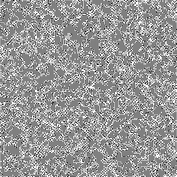

size = 1024, $δ = $ 0.4, iter = 500000, temp_start = 1

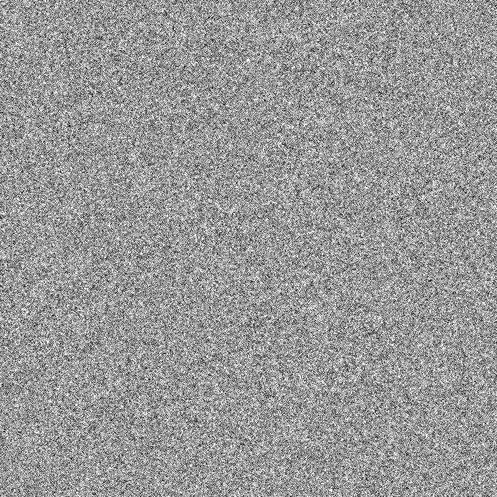

## Funkcje bazujące na ułożeniu punktu na mapie

### 7. Center

Wprowadzam prostą zasadę, zgodnie z którą punkty czarne mają tendencję do unikania centralnych obszarów. Funkcja kosztu jest proporcjonalna do odległości od środka, penalizując umiejscowienie czarnych punktów zbliżonych do centrum, co w efekcie prowadzi do ich rozmieszczania się na obrzeżach.

```python
# kolory lubią być koło swoich
def center_ceil_val(M, x, y, val):
    n = len(M)
    sr = n//2
    return math.sqrt((x-sr)**2 + (y-sr)**2) if val == 1 else 0
```

Wizualizacje i gify

```python
implement_fun_for_matrix(center_ceil_val, "center")
```

size = 128, $δ = $ 0.3, iter = 500000, temp_start = 1

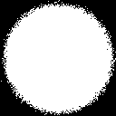

size = 256, $δ = $ 0.3, iter = 500000, temp_start = 1

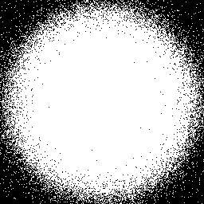

size = 1024, $δ = $ 0.1, iter = 500000, temp_start = 1

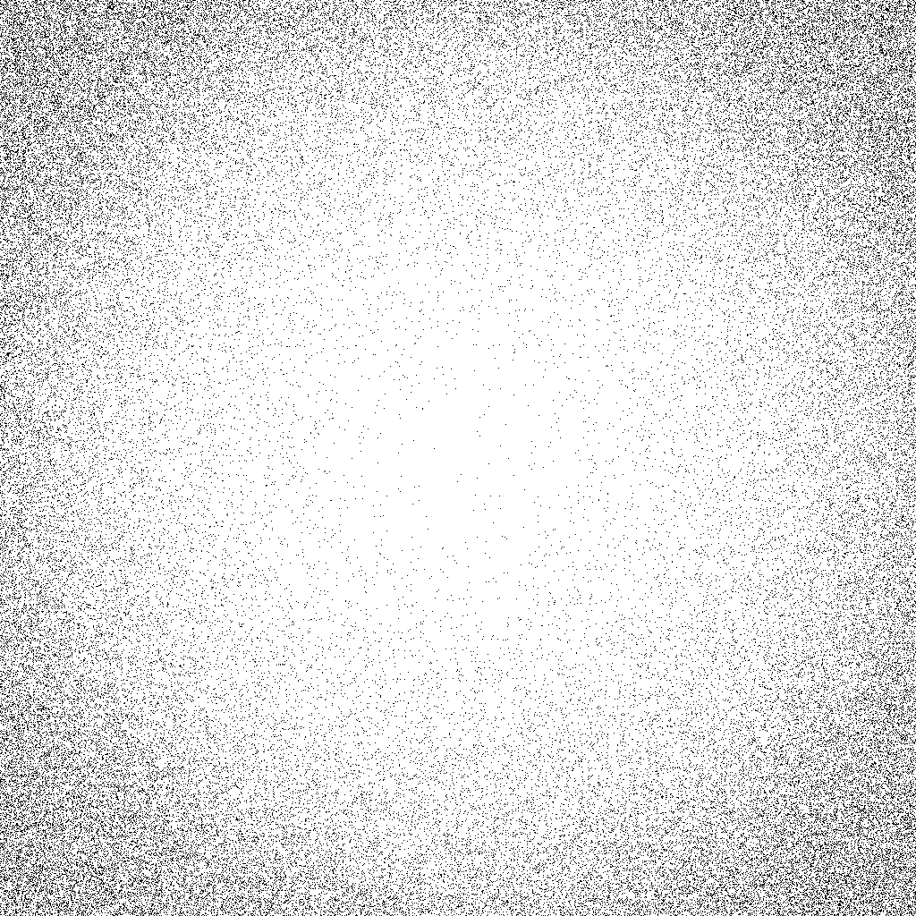

Jak widać na powyższych ilustracjach, na wierzchołkach i krawędziach obrazu tworzy się wyraźne zagęszczenie czarnych punktów. To zjawisko jest wynikiem wprowadzonej zasady, która penalizuje obecność czarnych punktów w centralnych częściach obrazu, kierując je ku brzegom.

### 8. 8 pasów

Funkcja ma na celu podział punktów na osiem poziomych obszarów na mapie, przypisując je do odpowiednich kategorii w zależności od ich pozycji wzdłuż osi poziomej.

```python
def eight_streaks_cell_value(M, x, y, val):
    n = len(M)
    kw = n//8
    if (x<kw or 2*kw<x<3*kw or 4*kw<x<5*kw or 6*kw<x<7*kw):
        if val == 1:
            return 1
    else:
        if val == 0:
            return 1
    return 0
```

Wizualizacje i gify

```python
implement_fun_for_matrix(eight_streaks_cell_value, "streaks")
```

size = 128, $δ = $ 0.4, iter = 500000, temp_start = 1

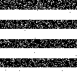

size = 256, $δ = $ 0.4, iter = 500000, temp_start = 1

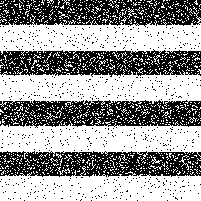

size = 1024, $δ = $ 0.4, iter = 500000, temp_start = 1

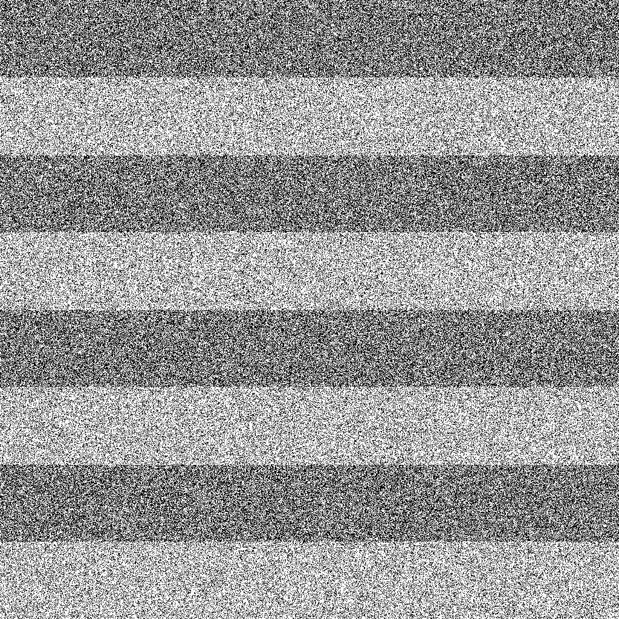

Jak widać powyżej, na obrazach wyraźnie widoczne są pasy, które wynikają z zastosowanego podziału na poziome obszary.

### 9. Big chess

Funkcja ma na celu podzielenie obszaru na mniejsze podobszary, które będą tworzyć strukturę przypominającą dużą szachownicę.

```python
# 8 pasów
def get_value_like_matrix_bigchess(M, x, y, val):
    n = len(M)
    kw = n//8
    if (x<kw or 2*kw<x<3*kw or 4*kw<x<5*kw or 6*kw<x<7*kw)/
    and (y<kw or 2*kw<y<3*kw or 4*kw<y<5*kw or 6*kw<y<7*kw):
        if val == 1:
            return 1
    else:
        if val == 0:
            return 1
    return 0
```

Wizualizacje i gify

```python
implement_fun_for_matrix(get_value_like_matrix_bigchess, "big_chess")
```

size = 128, $δ = $ 0.3, iter = 500000, temp_start = 1

[figure not shown]

size = 256, $δ = $ 0.1, iter = 500000, temp_start = 1

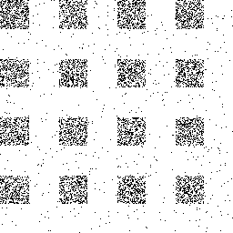

size = 1024, $δ = $ 0.3, iter = 500000, temp_start = 1

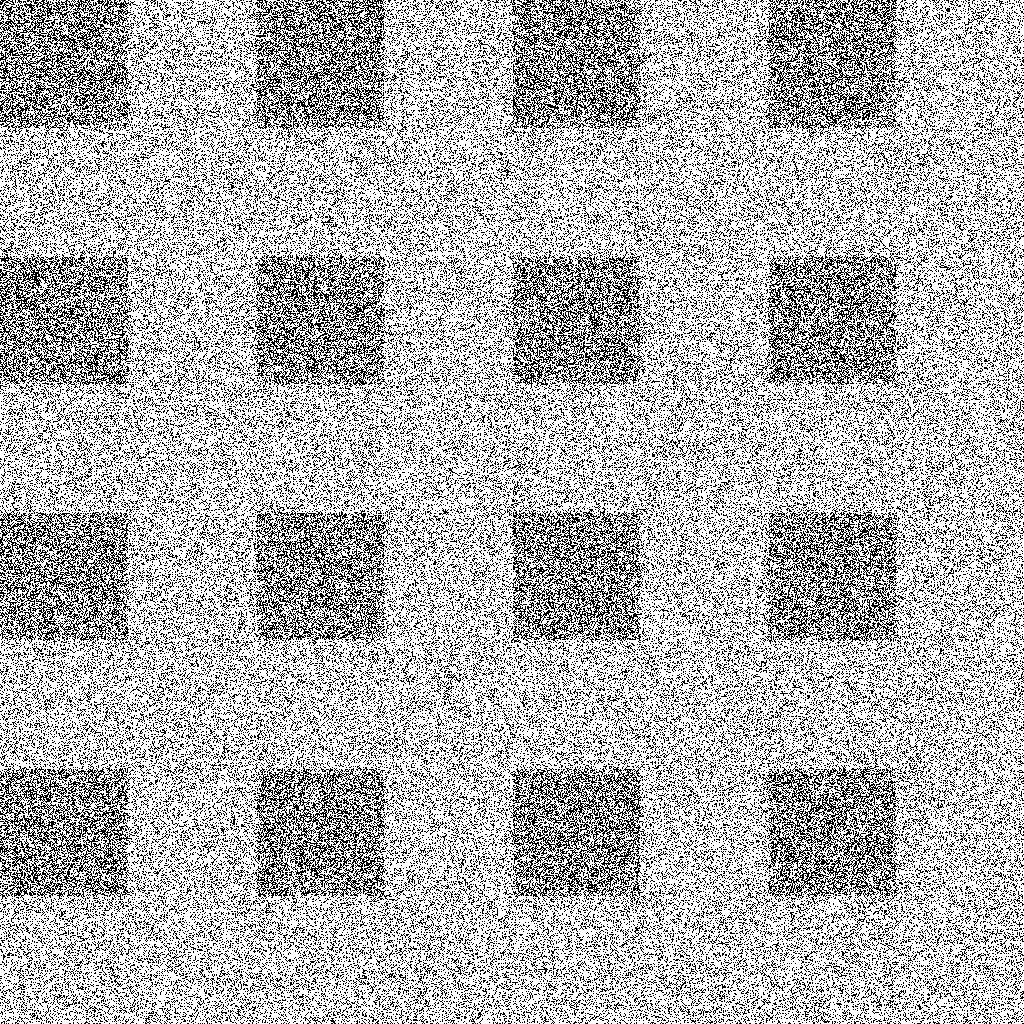

Układ szachownicy jest widoczny na każdym rozmiarze obrazu.

## Dodatkowy czerwony kolor

### Modyfikacja poprzednich funkcji wizualizujących wyniki

W celu wprowadzenia dodatkowego koloru potrzebna jest lekka modyfikacja poniższych funkcji

```python
def create_image_from_array(matrix):
    h, w = matrix.shape
    img = np.zeros((h, w, 3), dtype=np.uint8)  # 3 kanały: RGB
    img[matrix == 0] = [255, 255, 255]  # białe tło
    img[matrix == 1] = [0, 0, 0]        # czarne punkty
    img[matrix == 2] = [255, 0, 0]      # czerwony
    return Image.fromarray(img, mode='RGB')
```

```python
def draw_plot(matrix, path=None, folder_name=''):
    n = len(matrix)
    img = Image.new('RGB', (n, n))  # RGB - kolorowy obraz

    pixels = img.load()
    for i in range(n):
        for j in range(n):
            val = matrix[i, j]
            if val == 0:
                color = (255, 255, 255)  # biały
            elif val == 1:
                color = (0, 0, 0)        # czarny
            elif val == 2:
                color = (255, 0, 0)      # czerwony
            else:
                color = (128, 128, 128)  # kolor awaryjny dla nieznanych wartości
            pixels[j, i] = color

    # Upewnij się, że folder istnieje
    output_path = f"zad2_images/images/{folder_name}"
    # Zapisz obraz
    img.save(f"{output_path}/{path}.png")
```

```python
def extend_gif(matrix,images):
    n = len(matrix)
    img = Image.new('RGB', (n, n))  # RGB - kolorowy obraz

    pixels = img.load()
    for i in range(n):
        for j in range(n):
            val = matrix[i, j]
            if val == 1:
                color = (255, 255, 255)  # biały
            elif val == 0:
                color = (0, 0, 0)        # czarny
            elif val == 2:
                color = (255, 0, 0)      # czerwony
            else:
                color = (128, 128, 128)  # kolor awaryjny dla nieznanych wartości
            pixels[j, i] = color

    images.append(img) # 0 to biały, 1 to czarny
    return images
```

### Funkcja kosztu

```python
def get_black_like_red(M, x, y, val):
    # kolory lubią być koło swoich
    n = len(M)
    total = 0
    for dx in [-3, 0, 3]:
        for dy in [-3, 0, 3]:
            if dx == 0 and dy == 0:
                continue  # pomijamy środek
            nx, ny = x + dx, y + dy
            if 0 <= nx < n and 0 <= ny < n:
                if M[nx][ny] == 2 and val ==1:
                    total += 1
                if M[nx][ny] == 1 and val ==2:
                    total += 1
    return total
```

Wizualizacje i gify

```python
def implement_fun_for_matrix_red(fun_to_optymalize, name):
    t_delta = [0.1,0.3,0.4]
    t_iter = [500000]
    t_size = [128,256,512,1024]

    for iter in t_iter:
            for delta in t_delta:
                for size in t_size:
                    old_array = np.random.choice([0, 1, 2], size=(size//2, size//2), p=[delta, 1-delta-0.03,0.03])
                    new_array = np.random.choice([0, 1], size=(size, size), p=[delta, 1 - delta])
                    new_array[size//4:3*size//4, size//4:3*size//4] = old_array
                    matrix, t, _ = create_cristal(new_array ,
                                    fun_to_optymalize,
                                    1,
                                    iter,
                                    min_heat=1e-18,
                                    fun_change_par=0.99999,

                                    gif_name=f"{name}/{name}_{size}x{size}_{delta}_{iter}")
                    draw_linear_plot(t,f"{name}_{size}x{size}_{delta}_{iter}",name)
                    draw_plot(matrix,f"{name}_{size}x{size}_{delta}_{iter}.png",name)

implement_fun_for_matrix_red(get_black_like_red, "red_like")
```

size = 128, $δ = $ 0.1, iter = 500000, temp_start = 1

[figure not shown]

size = 256, $δ = $ 0.1, iter = 500000, temp_start = 1

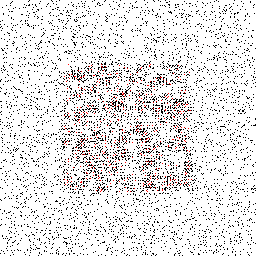

size = 512, $δ = $ 0.1, iter = 500000, temp_start = 1

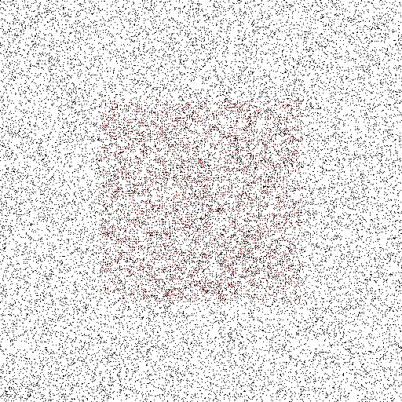